# NLP with LLMs

Published

November 24, 2023

# 1 Sentiment Analysis

In this Exercise set, we are going to use ChatGPT for a sentiment analysis problem. We’ll be using the API, along with the prompting lessons we learned in previous lectures.

## 1.1 Environment setup

Load all the libraries we will need. You may need to install some of these libraries.

```r
library(tidyverse)
library(caret)
library(kableExtra)
library(knitr)
library(glue)
library(yaml)
library(jsonlite)

# Loading the API_KEY
file_path <- "../../credentials.yml"
credentials <- yaml.load_file(file_path)
OPENAI_API_KEY <- credentials$OPENAI_API_KEY
```

We will also load some utility functions I have written for you so you don’t have to. You can find them under `./utils/`:

```r
utils_dir <- "./utils/"

# Fetch utils from utils directory
for (file in list.files(utils_dir)) {
  source(paste0(utils_dir, file))
}
```

Please check out the Documentation under `./utils/chat_completion.R` to get an overview of what the `generate_completion` function looks like. It is very similar to the function as provided by `library(openai)`, but offers the added ability to call the format specifier which was a new feature that has not yet been implemented in the `openai` library. This feature that has only been around since Dev-Day (November 6th 2023). It also offers some extra convenience with regards to building the prompts. You can choose to either use a `system_prompt` and a `user_prompt`, or a list of `messages`. The `messages` will override any other prompts you set. For the system and user prompts it uses glue, so you don’t have to! You can also specify whether the function should print the response or not.

## 1.2 Read the data

The dataset contains 500 sentences of the SemEval2014-restaurants dataset. This is a dataset for ABSA:  
“Aspect Based Sentiment Analysis”: Given all the aspects (red: relevant elements) detect the sentiment expressed about them.

There are 2 flavours of ABSA:

- regular ABSA: Detect the sentiment for each aspect given.
- E2E-ABSA: End-to-End Aspect Based Sentiment Analysis; Detect both the aspects and their sentiment.

E2E is significantly harder to achieve, and to a higher degree depends on the labeling quality of the data set. For this exercise set, we will be performing regular ABSA using an LLM.

```r
# Read the data
data_x <- read_csv2("./data/semEval2014-restaurants-x.csv")
data_y <- read_csv2("./data/semEval2014-restaurants-y.csv")


# DON'T TOUCH THIS CODE ---------------------##
# We need everybodies data_test to be equal  ##
#--------------------------------------------##
# Not all sentences in the dataset have a y-label in the original data set
# in this cleaned sample they do
data <- data_x %>% inner_join(data_y, by = "sentence_id")

data_train <- data %>%
  group_by(sentence_id) %>%
  mutate(new_id = cur_group_id()) %>%
  ungroup() %>%
  filter(new_id <= 400) %>%
  select(-new_id)

data_test <- data %>%
  group_by(sentence_id) %>%
  mutate(new_id = cur_group_id()) %>%
  ungroup() %>%
  filter(new_id > 400) %>%
  select(-new_id)
#--------------------------------------------##
```

### 1.2.1 Check out the data, what does it look like

You can use `%>% kable() %>% kable_styling()` to get a nice looking table in the inline output.

```r
data_train %>%
  head(10) %>%
  kable() %>%
  kable_styling()
```

| sentence_id | sentence_text | aspect_term | polarity |
| --- | --- | --- | --- |
| 1634 | The food is uniformly exceptional, with a very capable kitchen which will proudly whip up whatever you feel like eating, whether it's on the menu or not. | food | positive |
| 1634 | The food is uniformly exceptional, with a very capable kitchen which will proudly whip up whatever you feel like eating, whether it's on the menu or not. | kitchen | positive |
| 1634 | The food is uniformly exceptional, with a very capable kitchen which will proudly whip up whatever you feel like eating, whether it's on the menu or not. | menu | neutral |
| 1458 | Our agreed favorite is the orrechiete with sausage and chicken (usually the waiters are kind enough to split the dish in half so you get to sample both meats). | orrechiete with sausage and chicken | positive |
| 1458 | Our agreed favorite is the orrechiete with sausage and chicken (usually the waiters are kind enough to split the dish in half so you get to sample both meats). | waiters | positive |
| 1458 | Our agreed favorite is the orrechiete with sausage and chicken (usually the waiters are kind enough to split the dish in half so you get to sample both meats). | meats | neutral |
| 1458 | Our agreed favorite is the orrechiete with sausage and chicken (usually the waiters are kind enough to split the dish in half so you get to sample both meats). | dish | neutral |
| 1407 | The seats are uncomfortable if you are sitting against the wall on wooden benches. | seats | negative |
| 1623 | The wine list is excellent. | wine list | positive |
| 1101 | They wouldnt even let me finish my glass of wine before offering another. | glass of wine | neutral |

```r
data_train %>%
  group_by(polarity) %>%
  summarize(count = n() / nrow(data_train) * 100) %>%
  kable(digits=2) %>%
  kable_styling()
```

| polarity | count |
| --- | --- |
| conflict | 2.24 |
| negative | 24.40 |
| neutral | 15.43 |
| positive | 57.92 |

# 2 ABSA

Here we will try our hand at sentiment analysis using an out-of-the-box LLM.  
*IMPORTANT-RULE:*  
You are allowed to do whatever you want with the training data. Play with it, experiment with it, etc. But you are only allowed to touch the test-data when we evaluate our model performance. If you need to alter the format of data_test for your prompt, that is allowed, but other than that, you cannot touch it! We will see who get’s the highest test-performance at the end of the session.

## 2.1 Zero-shot - Single

At this point, we are going to try performing Zero-shot sentiment analysis. The rules are simple:

- The model response should contain the prediction for all aspects in the same sentence at once.
- You are not allowed to provide any sentiment analysis examples to the model.
- You are allowed to describe the various sentiment polarities and their definition.
- You are free to write this prompt as you see fit, just don’t give examples.
- You can decide how to distribute the prompt over the system_prompt and the user_prompt.
- Check out the labeling rules guide for SemEval: `./data/SemEval14_ABSA_AnnotationGuidelines.pdf`
- Make it easy for yourself: use the json mode for easy extraction of the classifications!

**Example:**  
Here is an example to demonstrate what the data looks like, and what the expected output is.

Targets:

- sentence: “The food is uniformly exceptional, with a very capable kitchen which will proudly whip up whatever you feel like eating, whether it’s on the menu or not.”
- aspects: food, kitchen, menu
- sentiment: positive, positive, neutral

Output:

- {“food”: “positive”, “kitchen”: “positive”, “menu”: “neutral”}

Let us start with classifying the sentiment for a single example sentence.

```r
system_prompt <- "
  You are a sentiment labeling expert. You will be provided with a review along with a list of aspects. For each aspect, determine the sentiment polarity.
  Rules:
  Aspect term polarity: Each aspect term has to be assigned one of the following polarities based on the
  sentiment that is expressed in the sentence: positive, negative, conflict (both positive and negative sentiment), neutral (neither positive nor negative sentiment)

  Format your output as a .json with a polarity for each input aspect. Only return this json.
"

user_prompt <- "
  aspects: {target_aspect_terms_combined}
  sentence: {target_sentence}
"
```

```r
i <- 1
x_sentence_id <- data_train[[i, "sentence_id"]]
target_sentence <- data_train[[i, "sentence_text"]]

targets <- data_train %>% filter(sentence_id == x_sentence_id)
target_aspect_terms_combined <- paste(targets$aspect_term, collapse = ", ")
```

```r
response <- generate_completion(system_prompt, user_prompt)
```

```
**Response 1**:

{
  "food": "positive",
  "kitchen": "positive",
  "menu": "neutral"
}
```

### 2.1.1 Check if the predictions where correct

```r
# Read classifications from response
response_classifications <- fromJSON(response$choices$message.content)

# Check correctness for each prediction
results <- c()
for (i in seq_along(response_classifications)) {
  result_i <- response_classifications[[i]] == targets$polarity[targets$aspect_term == names(response_classifications)[[i]]]
  results <- c(results, result_i)
}
print(results)
```

```
[1] TRUE TRUE TRUE
```

You can play around a bit here, to test your prompt on individual examples. In the next section, I’ve supplied code you can use to test your prompt on multiple examples at once.

## 2.2 Zero-shot - Multiple examples

Now we’ll do a bigger trial run on the training data. Below I’ve written some code that puts all the data of the first 50 sentences into a single dataframe and runs predictions. You should finish the `get_predicitions` function to get predictions for every sentence in data_train

```r
n_samples <- 50

data_train_sample <- data_train %>%
  group_by(sentence_id) %>%
  mutate(new_id = cur_group_id()) %>%
  ungroup() %>%
  filter(new_id <= n_samples) %>%
  select(-new_id)

predict_sentiment <- function(system_prompt = system_prompt, user_prompt = user_prompt, messages = NULL, verbose=TRUE) {
  #' A simple wrapper function for generate completion that extracts the sentiment from the response
  #' Please modify to your own liking!
  response <- generate_completion(system_prompt, user_prompt, messages = messages, format = list("type" = "json_object"), verbose=verbose)
  response_classifications <- fromJSON(response$choices$message.content)
  return(response_classifications)
}

# We're making predictions in a for loop, and appending them to a dataframe
# Not elegant or vectorised, but easy to understand.
# please note: running this takes a while to finish...
sentence_ids <- unique(data_train_sample$sentence_id)
predictions_train <- data.frame(sentence_id = integer(), aspect_term = character(), prediction = character())
for (target_sentence_id in sentence_ids) {
  targets <- data_train_sample[data_train_sample$sentence_id == target_sentence_id, ]
  target_sentence <- targets[[1, "sentence_text"]]

  target_aspect_terms_combined <- paste(targets$aspect_term, collapse = ", ")

  prediction <- predict_sentiment(system_prompt, user_prompt, verbose=FALSE)
  for (j in seq_along(prediction)) {
    predictions_train <- rbind(predictions_train, data.frame(sentence_id = target_sentence_id, aspect_term = names(prediction)[[j]], polarity_prediction = prediction[[j]]))
  }
}
```

Bring them together so we can evaluate the accuracy

```r
data_train_p <- data_train_sample %>% left_join(predictions_train, by = c("sentence_id", "aspect_term"))
```

### 2.2.1 Evaluation Metrics

In this section you can evaluate the performance of your model. You will get:

- The accuracy
- Class level: Precision, Recall, Specificity

```r
# Create a confusion matrix
conf_matrix <- confusionMatrix(
  factor(data_train_p$polarity_prediction, levels = c("negative", "neutral", "positive", "conflict")),
  factor(data_train_p$polarity, levels = c("negative", "neutral", "positive", "conflict"))
)

# Extracting metrics
accuracy <- conf_matrix$overall["Accuracy"]

# Return the baseline a working model should at least beat in terms of accuracy.
baseline_accuracy <- max((data_train %>% group_by(polarity) %>% summarize(count = n()))$count) / nrow(data_train)

# Print the metrics
print(glue("The baseline accuracy (predicting majority class): {round(baseline_accuracy,3)}"))
```

```
The baseline accuracy (predicting majority class): 0.579
```

```r
print(glue("Micro Accuracy = Micro Precision = Micro Recall = Micro F1: {round(accuracy,3)}"))
```

```
Micro Accuracy = Micro Precision = Micro Recall = Micro F1: 0.831
```

```r
print(round(conf_matrix$byClass[, c("Precision", "Recall", "Specificity")], 3))
```

```
                Precision Recall Specificity
Class: negative     0.714  0.833       0.944
Class: neutral      0.600  0.692       0.914
Class: positive     0.961  0.891       0.929
Class: conflict     0.333  0.333       0.975
```

### 2.2.2 Confusion matrix

This code takes as input your confusion_matrix to turn it into a plot.

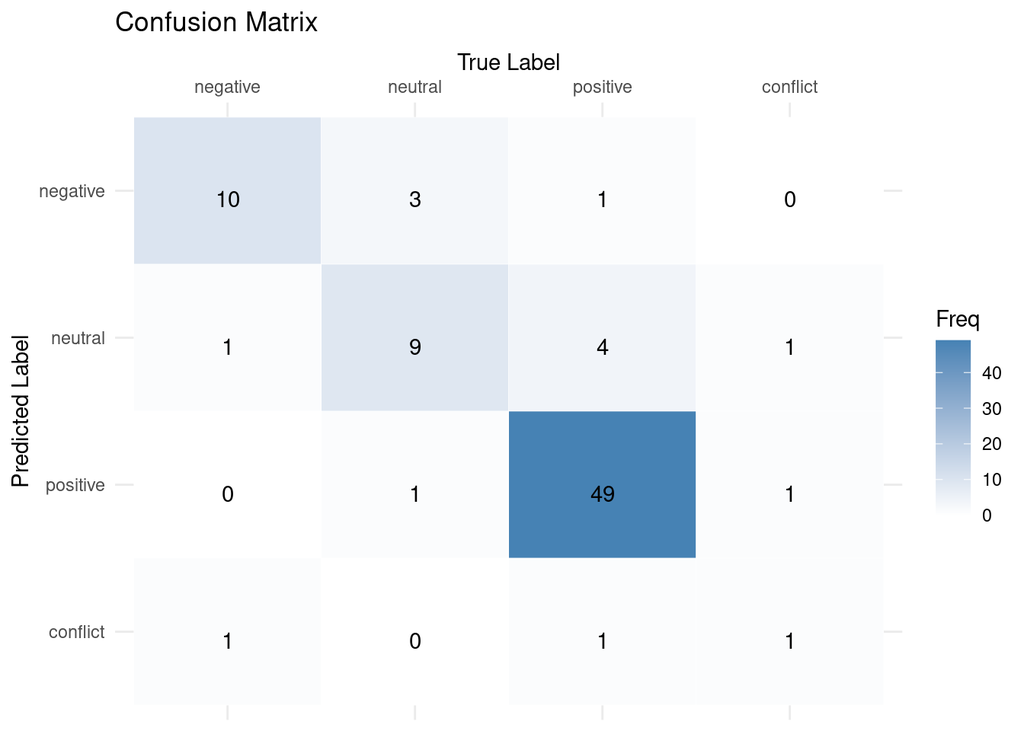

```r
plot_confusion_matrix <- function(conf_matrix) {
  # Convert to data frame for plotting
  matrix_df <- as.data.frame(conf_matrix$table)
  matrix_df$Prediction <- factor(matrix_df$Prediction, levels = rev(levels(matrix_df$Prediction)))

  # Plot using ggplot2
  plot <- ggplot(data = matrix_df, aes(x = Reference, y = Prediction)) +
    geom_tile(aes(fill = Freq), colour = "white") +
    geom_text(aes(label = sprintf("%0.0f", Freq)), vjust = 1) +
    scale_fill_gradient(low = "white", high = "steelblue") +
    theme_minimal() +
    xlab("True Label") +
    ylab("Predicted Label") +
    ggtitle("Confusion Matrix") +
    scale_x_discrete(position = "top")

  print(plot)
}
plot_confusion_matrix(conf_matrix)
```

### 2.2.3 Inspect the wrong predictions

Please check what the examples where the model got wrong.:

```r
data_train_p %>%
  group_by(sentence_id) %>%
  filter(any(polarity != polarity_prediction)) %>%
  ungroup() %>%
  select(sentence_text, aspect_term, polarity, polarity_prediction) %>%
  kable() %>%
  kable_styling()
```

| sentence_text | aspect_term | polarity | polarity_prediction |
| --- | --- | --- | --- |
| Food is usually very good, though ocasionally I wondered about freshmess of raw vegatables in side orders. | Food | conflict | positive |
| Food is usually very good, though ocasionally I wondered about freshmess of raw vegatables in side orders. | raw vegatables | negative | NA |
| The atmosphere is noisy and the waiters are literally walking around doing things as fast as they can. | atmosphere | negative | negative |
| The atmosphere is noisy and the waiters are literally walking around doing things as fast as they can. | waiters | conflict | neutral |
| The decor is vibrant and eye-pleasing with several semi-private boths on the right side of the dining hall, which are great for a date. | decor | positive | positive |
| The decor is vibrant and eye-pleasing with several semi-private boths on the right side of the dining hall, which are great for a date. | dining hall | positive | neutral |
| The decor is vibrant and eye-pleasing with several semi-private boths on the right side of the dining hall, which are great for a date. | semi-private boths | positive | positive |
| Try the congee and the donut like deep fried dough they call Ow Ley Soh, a delicious and sweet tasting bread. | congee | positive | neutral |
| Try the congee and the donut like deep fried dough they call Ow Ley Soh, a delicious and sweet tasting bread. | bread | positive | positive |
| Try the congee and the donut like deep fried dough they call Ow Ley Soh, a delicious and sweet tasting bread. | donut like deep fried dough they call Ow Ley Soh | positive | NA |
| In terms of the food itself -- nothing special, we limited ourselves to several appetizers. | food | neutral | neutral |
| In terms of the food itself -- nothing special, we limited ourselves to several appetizers. | appetizers | neutral | negative |
| We were fast to order the appetizer platter since we were very hungry. | appetizer platter | neutral | positive |
| night without a reservation, we had to wait at the bar for a little while, but the manager was so nice and made our wait a great experience. | manager | positive | positive |
| night without a reservation, we had to wait at the bar for a little while, but the manager was so nice and made our wait a great experience. | reservation | neutral | negative |
| night without a reservation, we had to wait at the bar for a little while, but the manager was so nice and made our wait a great experience. | bar | neutral | neutral |
| night without a reservation, we had to wait at the bar for a little while, but the manager was so nice and made our wait a great experience. | wait | positive | neutral |
| If anyones has doubt of not knowing enough about wines,please check their wine list. | wines | neutral | neutral |
| If anyones has doubt of not knowing enough about wines,please check their wine list. | wine list | positive | neutral |
| The food here is rather good, but only if you like to wait for it. | food | positive | conflict |
| I have known about this secret for the last 13 years, Emilio(the Godfather) has continued to serve food and wine for the gods at mortal prices. | food | positive | positive |
| I have known about this secret for the last 13 years, Emilio(the Godfather) has continued to serve food and wine for the gods at mortal prices. | wine | positive | positive |
| I have known about this secret for the last 13 years, Emilio(the Godfather) has continued to serve food and wine for the gods at mortal prices. | prices | positive | negative |
| The service is ok but could be better. | service | negative | conflict |
| Also, specify if you like your food spicy- its rather bland if you don't. | food | neutral | negative |
| However, if you want great food at a great price and don't mind the decor, you can't beat this place. | food | positive | positive |
| However, if you want great food at a great price and don't mind the decor, you can't beat this place. | price | positive | positive |
| However, if you want great food at a great price and don't mind the decor, you can't beat this place. | decor | negative | neutral |

Please check if there were examples where the model returned the wrong aspect label:

```r
data_train_sample %>%
  full_join(predictions_train, by = c("sentence_id", "aspect_term")) %>%
  group_by(sentence_id) %>%
  filter(any(is.na(polarity_prediction)) | any(is.na(polarity))) %>%
  ungroup() %>%
  arrange(sentence_id) %>%
  kable() %>%
  kable_styling()
```

| sentence_id | sentence_text | aspect_term | polarity | polarity_prediction |
| --- | --- | --- | --- | --- |
| 119 | Check out the secret back room. | secret back room | positive | NA |
| 119 | NA | secret | NA | positive |
| 119 | NA | back room | NA | neutral |
| 127 | The noodle and rices dishes taste great. | noodle and rices dishes | positive | NA |
| 127 | NA | noodle | NA | positive |
| 127 | NA | rices dishes | NA | positive |
| 140 | I fell in love with the egg noodles in the beef broth with shrimp dumplings and slices of BBQ roast pork. | egg noodles in the beef broth with shrimp dumplings and slices of BBQ roast pork | positive | NA |
| 140 | NA | egg noodles | NA | positive |
| 140 | NA | beef broth | NA | positive |
| 140 | NA | shrimp dumplings | NA | positive |
| 140 | NA | slices of BBQ roast pork | NA | positive |
| 142 | Try the congee and the donut like deep fried dough they call Ow Ley Soh, a delicious and sweet tasting bread. | congee | positive | neutral |
| 142 | Try the congee and the donut like deep fried dough they call Ow Ley Soh, a delicious and sweet tasting bread. | bread | positive | positive |
| 142 | Try the congee and the donut like deep fried dough they call Ow Ley Soh, a delicious and sweet tasting bread. | donut like deep fried dough they call Ow Ley Soh | positive | NA |
| 142 | NA | donut | NA | positive |
| 173 | Food is usually very good, though ocasionally I wondered about freshmess of raw vegatables in side orders. | Food | conflict | positive |
| 173 | Food is usually very good, though ocasionally I wondered about freshmess of raw vegatables in side orders. | raw vegatables | negative | NA |
| 173 | NA | raw vegetables | NA | conflict |
| 182 | I like the somosas, chai, and the chole, but the dhosas and dhal were kinda dissapointing. | somosas | positive | NA |
| 182 | I like the somosas, chai, and the chole, but the dhosas and dhal were kinda dissapointing. | chai | positive | positive |
| 182 | I like the somosas, chai, and the chole, but the dhosas and dhal were kinda dissapointing. | chole | positive | positive |
| 182 | I like the somosas, chai, and the chole, but the dhosas and dhal were kinda dissapointing. | dhosas | negative | negative |
| 182 | I like the somosas, chai, and the chole, but the dhosas and dhal were kinda dissapointing. | dhal | negative | negative |
| 182 | NA | samosas | NA | positive |

The model corrects misspelled words in the current version, and it sometimes splits terms into 2 or more terms where it shouldn’t

## 2.3 Zero-shot - Test

You can still iterate over your zero-shot prompt above, using all the information from the train set, or using a larger sample of the training-data. If you are ready to test yourself, run the cell below to evaluate your model on the test-set.

**YOU ARE ONLY ALLOWED TO DO THIS ONCE, THIS WILL BE YOUR FINAL SCORE ON THE ZERO-SHOT EXERCISE**

```r
# We're making predictions in a for loop, and appending them to a dataframe
# Not elegant or vectorised, but easy to understand.
# please note: running this takes a while to finish...

sentence_ids <- unique(data_test$sentence_id)
predictions_test <- data.frame(sentence_id = integer(), aspect_term = character(), prediction = character())
for (target_sentence_id in sentence_ids) {
  targets <- data_test[data_test$sentence_id == target_sentence_id, ]
  target_sentence <- targets[[1, "sentence_text"]]

  target_aspect_terms_combined <- paste(targets$aspect_term, collapse = ", ")

  prediction <- predict_sentiment(system_prompt, user_prompt, verbose=FALSE)
  for (j in seq_along(prediction)) {
    predictions_test <- rbind(predictions_test, data.frame(sentence_id = target_sentence_id, aspect_term = names(prediction)[[j]], polarity_prediction = prediction[[j]]))
  }
}

data_test_p <- data_test %>% right_join(predictions_test, by = c("sentence_id", "aspect_term"))

# Create a confusion matrix
conf_matrix <- confusionMatrix(
  factor(data_test_p$polarity_prediction, levels = c("negative", "neutral", "positive", "conflict")),
  factor(data_test_p$polarity, levels = c("negative", "neutral", "positive", "conflict"))
)

# Extracting metrics
accuracy <- conf_matrix$overall["Accuracy"]

# Print the metrics
print(glue("The baseline accuracy (predicting majority class): {round(baseline_accuracy,3)}"))
```

```
The baseline accuracy (predicting majority class): 0.579
```

```r
print(glue("Micro Accuracy = Micro Precision = Micro Recall = Micro F1: {round(accuracy,3)}"))
```

```
Micro Accuracy = Micro Precision = Micro Recall = Micro F1: 0.791
```

```r
print(round(conf_matrix$byClass[, c("Precision", "Recall", "Specificity")], 3))
```

```
                Precision Recall Specificity
Class: negative     0.846  0.805       0.949
Class: neutral      0.600  0.400       0.938
Class: positive     0.816  0.964       0.760
Class: conflict     0.000  0.000       0.994
```

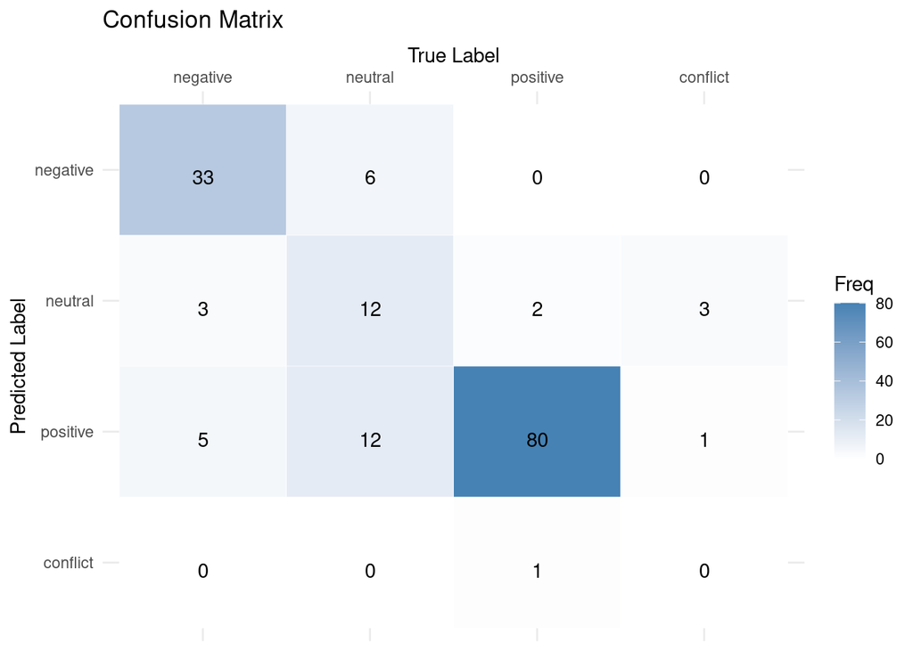

```r
plot_confusion_matrix(conf_matrix)
```

## 2.4 Few-shot - Training

Now adjust your system prompt, use examples to demonstrate how labels should be given. You can only use examples from the training set, or examples that you thought of yourself.

```r
system_prompt <- "
  You are a sentiment labeling expert. You will be provided with a review along with a list of aspects. For each aspect, determine the sentiment polarity. Only make predictions for the aspects given.
  Rules:
  Aspect term polarity: Each aspect term has to be assigned one of the following polarities based on the
  sentiment that is expressed in the sentence: positive, negative, conflict (both positive and negative sentiment), neutral (neither positive nor negative sentiment)

  Format your output as a .json with a polarity for each input aspect. Only return this json.
"

user_prompt <- "
  aspects: {target_aspect_terms_combined}
  sentence: {target_sentence}
"

messages <- list(
  list(
    "role" = "system",
    "content" = glue(system_prompt)
  ),
  list(
    "role" = "user",
    "content" = "
      aspects: Food, raw vegatables
      sentence: Food is usually very good, though ocasionally I wondered about freshmess of raw vegatables in side orders.
    "
  ),
  list(
    "role" = "assistant",
    "content" = '{\n  "Food": "conflict",\n  "raw vegatables": "negative"\n}'
  ),
  list(
    "role" = "user",
    "content" = "
      aspects: drinks, appetizers
      sentence: Went on a double date with friend and his girlfriend for a few drinks and appetizers
    "
  ),
  list(
    "role" = "assistant",
    "content" = '{\n  "drinks": "neutral",\n  "appetizers": "neutral"\n}'
  ),
  list(
    "role" = "user",
    "content" = "
      aspects: manager, reservation, bar, wait
      sentence: night without a reservation, we had to wait at the bar for a little while, but the manager was so nice and made our wait a great experience.
    "
  ),
  list(
    "role" = "assistant",
    "content" = '{\n  "manager": "positive",\n  "reservation": "neutral", "bar": "neutral", "wait":"positive"\n}'
  ),
  list(
    "role" = "user",
    "content" = "
      aspects: wine, prices
      sentence: I have known about this secret for the last 13 years, Emilio(the Godfather) has continued to serve food and wine for the gods at mortal prices.
    "
  ),
  list(
    "role" = "assistant",
    "content" = '{\n  "wine": "positive",\n  "prices": "positive"\n}'
  )
)
```

## 2.5 Few-shot - Test

You can still iterate over your few-shot prompt above, using all the information from the train set, or using a larger sample of the training-data. If you are ready to test yourself, run the cell below to evaluate your model on the test-set.

**YOU ARE ONLY ALLOWED TO DO THIS ONCE, THIS WILL BE YOUR FINAL SCORE ON THE FEW-SHOT EXERCISE**

```r
# We're making predictions in a for loop, and appending them to a dataframe
# Not elegant or vectorised, but easy to understand.
# please note: running this takes a while to finish...

sentence_ids <- unique(data_test$sentence_id)
predictions_test <- data.frame(sentence_id = integer(), aspect_term = character(), prediction = character())
for (target_sentence_id in sentence_ids) {
  targets <- data_test[data_test$sentence_id == target_sentence_id, ]
  target_sentence <- targets[[1, "sentence_text"]]

  target_aspect_terms_combined <- paste(targets$aspect_term, collapse = ", ")

  user_prompt_message <- list(
    "role" = "user",
    "content" = glue(user_prompt)
  )

  messages_input <- messages
  messages_input[[length(messages) + 1]] <- user_prompt_message
  prediction <- predict_sentiment(messages = messages_input, verbose=FALSE)
  for (j in seq_along(prediction)) {
    predictions_test <- rbind(predictions_test, data.frame(sentence_id = target_sentence_id, aspect_term = names(prediction)[[j]], polarity_prediction = prediction[[j]]))
  }
}

data_test_p <- data_test %>% left_join(predictions_test, by = c("sentence_id", "aspect_term"))

# Create a confusion matrix
conf_matrix <- confusionMatrix(
  factor(data_test_p$polarity_prediction, levels = c("negative", "neutral", "positive", "conflict")),
  factor(data_test_p$polarity, levels = c("negative", "neutral", "positive", "conflict"))
)

# Extracting metrics
accuracy <- conf_matrix$overall["Accuracy"]

# Print the metrics
print(glue("The baseline accuracy (predicting majority class): {round(baseline_accuracy,3)}"))
```

```
The baseline accuracy (predicting majority class): 0.579
```

```r
print(glue("Micro Accuracy = Micro Precision = Micro Recall = Micro F1: {round(accuracy,3)}"))
```

```
Micro Accuracy = Micro Precision = Micro Recall = Micro F1: 0.785
```

```r
print(round(conf_matrix$byClass[, c("Precision", "Recall", "Specificity")], 3))
```

```
                Precision Recall Specificity
Class: negative     0.791  0.829       0.923
Class: neutral      0.542  0.433       0.914
Class: positive     0.846  0.928       0.813
Class: conflict        NA  0.000       1.000
```

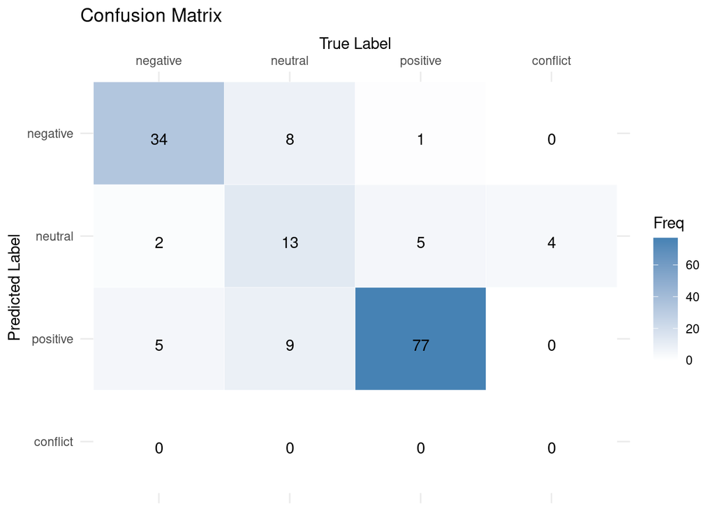

```r
plot_confusion_matrix(conf_matrix)
```